# Prediction Assignment Writeup

2022-04-19

*by Ignat Krukovskiy*

## Overview

In this course project we predict the manner in which people did the exercises. One thing that people regularly do is quantify how much of a particular activity they do, but they rarely quantify how well they do it. In this project, your goal will be to use data from accelerometers on the belt, forearm, arm, and dumbell of 6 participants.

### Preparations

First we prepare environment for the investigation

```r
library(knitr)
library(caret)
library(rpart)
library(corrplot)
library(RColorBrewer)
library(gbm)
library(rpart)
```

Load raw data from working directory

```r
raw_train <- read.csv("pml-training.csv")
raw_test <- read.csv("pml-testing.csv")
```

### Data preprocessing

We split training dataset (raw_train) by 2 datasets: trainig and test (e.g. debug)

```r
inTrain  <- createDataPartition(raw_train$classe, p=0.7, list=FALSE)
train_set <- raw_train[inTrain, ]
test_set  <- raw_train[-inTrain, ]
dim(train_set)
```

```
## [1] 13737   160
```

The training set contains 160 columns with 13737. Now we exclue columns and observations that don’t impact to our model.

Indicate columns with the near zero variance

```r
nzv <- nearZeroVar(train_set)
```

Exclude nzv columns from dataset

```r
train_set <- train_set[, -nzv]
test_set <- test_set[, -nzv]
dim(train_set)
```

```
## [1] 13737   104
```

```r
mostlyNA <- sapply(train_set, function(x){
  mean(is.na(x)) > .95
  })
train_set <- train_set[, mostlyNA == FALSE]
test_set <- test_set[, mostlyNA == FALSE]
dim(train_set)
```

```
## [1] 13737    59
```

Only 59 columns left that have impact to the model

```r
train_set <- train_set[, -(1:5)]
test_set <- test_set[, -(1:5)]
names(train_set)
```

```
##  [1] "num_window"           "roll_belt"            "pitch_belt"
##  [4] "yaw_belt"             "total_accel_belt"     "gyros_belt_x"
##  [7] "gyros_belt_y"         "gyros_belt_z"         "accel_belt_x"
## [10] "accel_belt_y"         "accel_belt_z"         "magnet_belt_x"
## [13] "magnet_belt_y"        "magnet_belt_z"        "roll_arm"
## [16] "pitch_arm"            "yaw_arm"              "total_accel_arm"
## [19] "gyros_arm_x"          "gyros_arm_y"          "gyros_arm_z"
## [22] "accel_arm_x"          "accel_arm_y"          "accel_arm_z"
## [25] "magnet_arm_x"         "magnet_arm_y"         "magnet_arm_z"
## [28] "roll_dumbbell"        "pitch_dumbbell"       "yaw_dumbbell"
## [31] "total_accel_dumbbell" "gyros_dumbbell_x"     "gyros_dumbbell_y"
## [34] "gyros_dumbbell_z"     "accel_dumbbell_x"     "accel_dumbbell_y"
## [37] "accel_dumbbell_z"     "magnet_dumbbell_x"    "magnet_dumbbell_y"
## [40] "magnet_dumbbell_z"    "roll_forearm"         "pitch_forearm"
## [43] "yaw_forearm"          "total_accel_forearm"  "gyros_forearm_x"
## [46] "gyros_forearm_y"      "gyros_forearm_z"      "accel_forearm_x"
## [49] "accel_forearm_y"      "accel_forearm_z"      "magnet_forearm_x"
## [52] "magnet_forearm_y"     "magnet_forearm_z"     "classe"
```

### Exploratory analysis

Now we gonna find correlations between variables

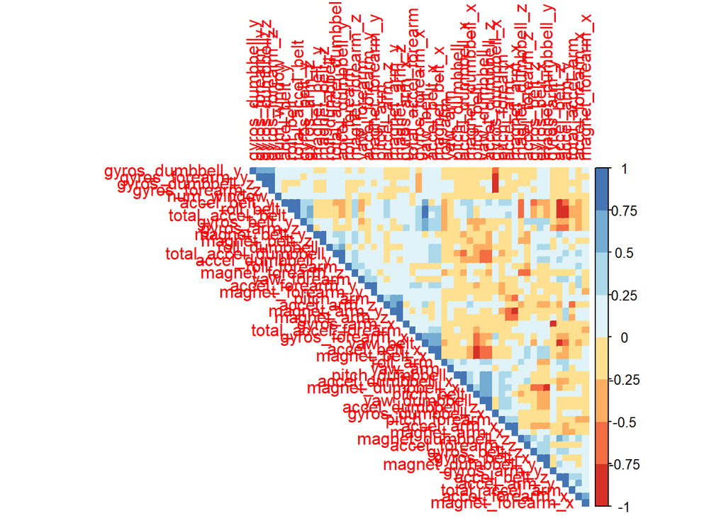

```r
corMatrix <- cor(train_set[, -54])
corrplot(corMatrix, order = "hclust", method = "color", type = "upper",
         col=brewer.pal(n=8, name="RdYlBu"))
```

### Model fit

Now we gonna fit two models and compare them

#### 1. Random forest

Fit the model

```r
set.seed(111)
control_forest <- trainControl(method="cv", number=3, verboseIter=FALSE)
modeled_fit_rf <- train(classe ~ ., data=train_set, method="rf",
                          trControl=control_forest)
modeled_fit_rf$finalModel
```

```
##
## Call:
##  randomForest(x = x, y = y, mtry = min(param$mtry, ncol(x)))
##                Type of random forest: classification
##                      Number of trees: 500
## No. of variables tried at each split: 27
##
##         OOB estimate of  error rate: 0.21%
## Confusion matrix:
##      A    B    C    D    E  class.error
## A 3904    1    0    0    1 0.0005120328
## B    7 2647    4    0    0 0.0041384500
## C    0    5 2391    0    0 0.0020868114
## D    0    0    7 2244    1 0.0035523979
## E    0    1    0    2 2522 0.0011881188
```

Test prediction

```r
predict_rf <- predict(modeled_fit_rf, newdata=test_set)
conf_rf <- confusionMatrix(predict_rf, as.factor(test_set$classe))
conf_rf
```

```
## Confusion Matrix and Statistics
##
##           Reference
## Prediction    A    B    C    D    E
##          A 1674    0    0    0    0
##          B    0 1139    0    0    0
##          C    0    0 1026    2    0
##          D    0    0    0  962    3
##          E    0    0    0    0 1079
##
## Overall Statistics
##
##                Accuracy : 0.9992
##                  95% CI : (0.998, 0.9997)
##     No Information Rate : 0.2845
##     P-Value [Acc > NIR] : < 2.2e-16
##
##                   Kappa : 0.9989
##
##  Mcnemar's Test P-Value : NA
##
## Statistics by Class:
##
##                      Class: A Class: B Class: C Class: D Class: E
## Sensitivity            1.0000   1.0000   1.0000   0.9979   0.9972
## Specificity            1.0000   1.0000   0.9996   0.9994   1.0000
## Pos Pred Value         1.0000   1.0000   0.9981   0.9969   1.0000
## Neg Pred Value         1.0000   1.0000   1.0000   0.9996   0.9994
## Prevalence             0.2845   0.1935   0.1743   0.1638   0.1839
## Detection Rate         0.2845   0.1935   0.1743   0.1635   0.1833
## Detection Prevalence   0.2845   0.1935   0.1747   0.1640   0.1833
## Balanced Accuracy      1.0000   1.0000   0.9998   0.9987   0.9986
```

# Fit the model

```r
control_gbm <- trainControl(method = "repeatedcv", number = 4, repeats = 2)
fit_gbm  <- train(classe ~ ., data=train_set, method = "gbm",
                    trControl = control_gbm, verbose = FALSE)
fit_gbm$finalModel
```

```
## A gradient boosted model with multinomial loss function.
## 150 iterations were performed.
## There were 53 predictors of which 53 had non-zero influence.
```

Test prediction

```r
predict_gbm <- predict(fit_gbm, newdata = test_set)
conf_gbm <- confusionMatrix(predict_gbm, as.factor(test_set$classe))
conf_gbm
```

```
## Confusion Matrix and Statistics
##
##           Reference
## Prediction    A    B    C    D    E
##          A 1669   13    0    0    0
##          B    4 1115    9    2    2
##          C    0    8 1015    8    2
##          D    1    0    0  953   11
##          E    0    3    2    1 1067
##
## Overall Statistics
##
##                Accuracy : 0.9888
##                  95% CI : (0.9858, 0.9913)
##     No Information Rate : 0.2845
##     P-Value [Acc > NIR] : < 2.2e-16
##
##                   Kappa : 0.9858
##
##  Mcnemar's Test P-Value : NA
##
## Statistics by Class:
##
##                      Class: A Class: B Class: C Class: D Class: E
## Sensitivity            0.9970   0.9789   0.9893   0.9886   0.9861
## Specificity            0.9969   0.9964   0.9963   0.9976   0.9988
## Pos Pred Value         0.9923   0.9850   0.9826   0.9876   0.9944
## Neg Pred Value         0.9988   0.9950   0.9977   0.9978   0.9969
## Prevalence             0.2845   0.1935   0.1743   0.1638   0.1839
## Detection Rate         0.2836   0.1895   0.1725   0.1619   0.1813
## Detection Prevalence   0.2858   0.1924   0.1755   0.1640   0.1823
## Balanced Accuracy      0.9970   0.9877   0.9928   0.9931   0.9924
```

### Conclusion

```r
predict_final <- predict(modeled_fit_rf, newdata=raw_test)
predict_final
```

```
##  [1] B A B A A E D B A A B C B A E E A B B B
## Levels: A B C D E
```